# House Pricing

**첫번째 접근법**

설명변수 전부를 넣고 *osl_step_all_possible()* 를 통해서 Mallow’s CP가 작은 몇개의 모델 선정한다.다음 train data에서 30% 추출한 test data로 prediction 했을 때 가장 작은 MSE를 가지는 모델을 최종 모델로 선정하고 실제 test data를 통해 prediction을 한다.

**첫번째 접근법의 문제**

1.*osl_step_all_possible()*를 하기에는 설명변수가 너무 많아서 실제로 *용량 부족*으로 함수가 돌아가지 않는다. 2. Train data에서 30% 추출하면서 남은 70%의 train data에 factor 변수의 *level 소실*.

**두번째 접근법**

이번에는 *osl_step_backward_p()*를 통해서 변수 하나씩을 제외하면서 최적의 모델을 선정하고 train data는 따로 생성하지 않는다.

**두번째 접근법의 문제**

1. *Over-fitting* 문제의 가능성
2. 실제 test data에 “NA” 데이터들이 포함되어 있어서 적합한 모델을 통한 추정값이 “NA”가 나온다. Submission rule에서 모든 열에 대한 추정값을 원하기 때문에 문제 이다.

**마지막 접근법의 문제**

1. 실제 test data만을 위한 어거지 모델이며 다른 test data가 주어지면 무용지물이 될 가능성이 있다.

```r
install.packages("tidyverse")
install.packages("olsrr")
library(dplyr)
library(olsrr)
library(magrittr)
```

**데이터 다운 및 NA 확인**

```r
train = read.csv("train.csv")
test = read.csv("test.csv")
summary(test)
```

```
##        Id         MSSubClass       MSZoning          LotFrontage
##  Min.   :1461   Min.   : 20.00   Length:1459        Min.   : 21.00
##  1st Qu.:1826   1st Qu.: 20.00   Class :character   1st Qu.: 58.00
##  Median :2190   Median : 50.00   Mode  :character   Median : 67.00
##  Mean   :2190   Mean   : 57.38                      Mean   : 68.58
##  3rd Qu.:2554   3rd Qu.: 70.00                      3rd Qu.: 80.00
##  Max.   :2919   Max.   :190.00                      Max.   :200.00
##                                                     NA's   :227
##     LotArea         Street             Alley             LotShape
##  Min.   : 1470   Length:1459        Length:1459        Length:1459
##  1st Qu.: 7391   Class :character   Class :character   Class :character
##  Median : 9399   Mode  :character   Mode  :character   Mode  :character
##  Mean   : 9819
##  3rd Qu.:11518
##  Max.   :56600
##
##  LandContour         Utilities          LotConfig          LandSlope
##  Length:1459        Length:1459        Length:1459        Length:1459
##  Class :character   Class :character   Class :character   Class :character
##  Mode  :character   Mode  :character   Mode  :character   Mode  :character
##
##
##
##
##  Neighborhood        Condition1         Condition2          BldgType
##  Length:1459        Length:1459        Length:1459        Length:1459
##  Class :character   Class :character   Class :character   Class :character
##  Mode  :character   Mode  :character   Mode  :character   Mode  :character
##
##
##
##
##   HouseStyle         OverallQual      OverallCond      YearBuilt
##  Length:1459        Min.   : 1.000   Min.   :1.000   Min.   :1879
##  Class :character   1st Qu.: 5.000   1st Qu.:5.000   1st Qu.:1953
##  Mode  :character   Median : 6.000   Median :5.000   Median :1973
##                     Mean   : 6.079   Mean   :5.554   Mean   :1971
##                     3rd Qu.: 7.000   3rd Qu.:6.000   3rd Qu.:2001
##                     Max.   :10.000   Max.   :9.000   Max.   :2010
##
```

[output cut: 105 more lines]

```
##  Length:1459        Length:1459        Length:1459        Min.   :    0.00
##  Class :character   Class :character   Class :character   1st Qu.:    0.00
##  Mode  :character   Mode  :character   Mode  :character   Median :    0.00
##                                                           Mean   :   58.17
##                                                           3rd Qu.:    0.00
##                                                           Max.   :17000.00
##
##      MoSold           YrSold       SaleType         SaleCondition
##  Min.   : 1.000   Min.   :2006   Length:1459        Length:1459
##  1st Qu.: 4.000   1st Qu.:2007   Class :character   Class :character
##  Median : 6.000   Median :2008   Mode  :character   Mode  :character
##  Mean   : 6.104   Mean   :2008
##  3rd Qu.: 8.000   3rd Qu.:2009
##  Max.   :12.000   Max.   :2010
##
```

NA 데이터들이 확인된다.

**NA를 포함하는 열을 제외**

```r
test2 = test %>%
  select_if(~ !any(is.na(.)))
  glimpse(test2)
```

```
## Rows: 1,459
## Columns: 47
## $ Id            <int> 1461, 1462, 1463, 1464, 1465, 1466, 1467, 1468, 1469, 14…
## $ MSSubClass    <int> 20, 20, 60, 60, 120, 60, 20, 60, 20, 20, 120, 160, 160, …
## $ LotArea       <int> 11622, 14267, 13830, 9978, 5005, 10000, 7980, 8402, 1017…
## $ Street        <chr> "Pave", "Pave", "Pave", "Pave", "Pave", "Pave", "Pave", …
## $ LotShape      <chr> "Reg", "IR1", "IR1", "IR1", "IR1", "IR1", "IR1", "IR1", …
## $ LandContour   <chr> "Lvl", "Lvl", "Lvl", "Lvl", "HLS", "Lvl", "Lvl", "Lvl", …
## $ LotConfig     <chr> "Inside", "Corner", "Inside", "Inside", "Inside", "Corne…
## $ LandSlope     <chr> "Gtl", "Gtl", "Gtl", "Gtl", "Gtl", "Gtl", "Gtl", "Gtl", …
## $ Neighborhood  <chr> "NAmes", "NAmes", "Gilbert", "Gilbert", "StoneBr", "Gilb…
## $ Condition1    <chr> "Feedr", "Norm", "Norm", "Norm", "Norm", "Norm", "Norm",…
## $ Condition2    <chr> "Norm", "Norm", "Norm", "Norm", "Norm", "Norm", "Norm", …
## $ BldgType      <chr> "1Fam", "1Fam", "1Fam", "1Fam", "TwnhsE", "1Fam", "1Fam"…
## $ HouseStyle    <chr> "1Story", "1Story", "2Story", "2Story", "1Story", "2Stor…
```

[output cut: 34 more lines]

**위에 모든 변수를 설명변수로 하는 lm 적합**

```r
fit = lm(SalePrice ~ MSSubClass + LotArea + Street + LotShape + LandContour + LotConfig +
              LandSlope + Neighborhood + Condition1 + Condition2 + BldgType + HouseStyle + OverallQual +
              OverallCond + YearBuilt + YearRemodAdd +  RoofStyle + RoofMatl + ExterQual + ExterCond +
              Foundation + Heating + HeatingQC + CentralAir + Electrical + X1stFlrSF + X2ndFlrSF +
              LowQualFinSF + FullBath + HalfBath + BedroomAbvGr +  KitchenAbvGr + TotRmsAbvGrd +
              Fireplaces + PavedDrive  + WoodDeckSF + OpenPorchSF + EnclosedPorch + X3SsnPorch + ScreenPorch +
              PoolArea + MiscVal + MoSold + YrSold + SaleCondition, train)
```

**backward 방식으로 AIC 기준으로 모델 선택**

```r
k = ols_step_backward_aic(fit)
fit2 = k$model
summary(fit2)
```

```
##
## Call:
## lm(formula = paste(response, "~", paste(preds, collapse = " + ")),
##     data = l)
##
## Residuals:
##     Min      1Q  Median      3Q     Max
## -170794  -13959    -114   12028  195121
##
## Coefficients:
##                        Estimate Std. Error t value Pr(>|t|)
## (Intercept)          -1.534e+06  1.430e+05 -10.724  < 2e-16 ***
## LotArea               8.055e-01  1.083e-01   7.436 1.84e-13 ***
## StreetPave            3.823e+04  1.298e+04   2.945 0.003282 **
## LandContourHLS        1.626e+04  5.706e+03   2.850 0.004433 **
## LandContourLow        3.832e+03  6.923e+03   0.554 0.579964
## LandContourLvl        8.406e+03  4.086e+03   2.057 0.039881 *
## LandSlopeMod          1.044e+04  4.317e+03   2.417 0.015772 *
## LandSlopeSev         -3.297e+04  1.167e+04  -2.826 0.004779 **
## NeighborhoodBlueste   1.082e+04  2.071e+04   0.523 0.601295
## NeighborhoodBrDale    1.664e+04  1.096e+04   1.519 0.129010
## NeighborhoodBrkSide   2.490e+03  9.158e+03   0.272 0.785757
## NeighborhoodClearCr  -3.751e+03  9.832e+03  -0.382 0.702886
## NeighborhoodCollgCr  -9.023e+02  7.693e+03  -0.117 0.906641
## NeighborhoodCrawfor   1.282e+04  8.940e+03   1.434 0.151724
## NeighborhoodEdwards  -9.579e+03  8.311e+03  -1.152 0.249332
## NeighborhoodGilbert  -1.318e+04  8.248e+03  -1.598 0.110185
## NeighborhoodIDOTRR   -3.337e+03  9.703e+03  -0.344 0.730994
## NeighborhoodMeadowV   9.078e+03  1.028e+04   0.883 0.377321
## NeighborhoodMitchel  -9.585e+03  8.569e+03  -1.119 0.263496
## NeighborhoodNAmes    -5.501e+03  8.102e+03  -0.679 0.497255
## NeighborhoodNoRidge   4.147e+04  8.688e+03   4.774 2.00e-06 ***
## NeighborhoodNPkVill   2.255e+04  1.180e+04   1.911 0.056207 .
## NeighborhoodNridgHt   4.110e+04  7.832e+03   5.248 1.78e-07 ***
## NeighborhoodNWAmes   -1.600e+04  8.452e+03  -1.893 0.058623 .
## NeighborhoodOldTown  -7.949e+03  8.845e+03  -0.899 0.369000
## NeighborhoodSawyer   -4.264e+03  8.553e+03  -0.499 0.618169
## NeighborhoodSawyerW  -1.018e+03  8.208e+03  -0.124 0.901355
## NeighborhoodSomerst   1.294e+04  7.716e+03   1.678 0.093656 .
## NeighborhoodStoneBr   5.245e+04  8.824e+03   5.945 3.51e-09 ***
```

[output cut: 63 more lines]

```
## ScreenPorch           4.364e+01  1.349e+01   3.235 0.001244 **
## PoolArea              8.823e+01  1.987e+01   4.441 9.68e-06 ***
## MoSold               -6.812e+02  2.719e+02  -2.505 0.012352 *
## SaleConditionAdjLand  1.349e+04  1.577e+04   0.856 0.392366
## SaleConditionAlloca  -1.720e+03  9.176e+03  -0.187 0.851352
## SaleConditionFamily   1.173e+03  6.799e+03   0.172 0.863079
## SaleConditionNormal   5.704e+03  2.934e+03   1.944 0.052078 .
## SaleConditionPartial  2.234e+04  4.165e+03   5.363 9.61e-08 ***
## ---
## Signif. codes:  0 '***' 0.001 '**' 0.01 '*' 0.05 '.' 0.1 ' ' 1
##
## Residual standard error: 27040 on 1359 degrees of freedom
##   (1 observation deleted due to missingness)
## Multiple R-squared:  0.8921, Adjusted R-squared:  0.8843
## F-statistic: 113.5 on 99 and 1359 DF,  p-value: < 2.2e-16
```

*유의하지 않는 변수*들이 보이나 prediction이 목적이기에 제거하지 않겠다.

**제거된 변수들**

```r
k$predictors
```

```
##  [1] "ExterCond"     "LotShape"      "PavedDrive"    "HeatingQC"
##  [5] "Heating"       "CentralAir"    "MSSubClass"    "HalfBath"
##  [9] "YrSold"        "FullBath"      "EnclosedPorch" "YearRemodAdd"
## [13] "MiscVal"       "LotConfig"     "X3SsnPorch"    "OpenPorchSF"
## [17] "TotRmsAbvGrd"
```

**Residuals 확인**

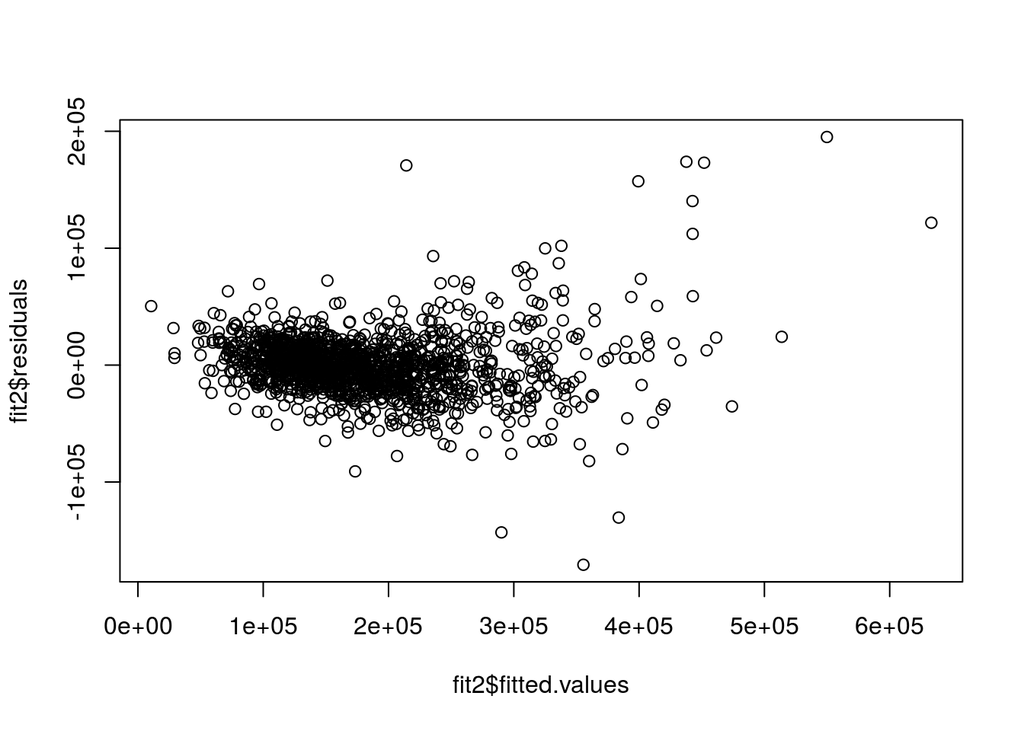

```r
plot(fit2$fitted.values, fit2$residuals)
```

분산이 일정해 보이지 않기에 SalePrice에 log를 취하겠다.

```r
fit3 = lm(log(SalePrice) ~  LotArea + Street +  LandContour +
              LandSlope + Neighborhood + Condition1 + Condition2 + BldgType + HouseStyle + OverallQual +
              OverallCond + YearBuilt +  RoofStyle + RoofMatl + ExterQual +
              Foundation +  Electrical + X1stFlrSF + X2ndFlrSF +
              LowQualFinSF +  BedroomAbvGr +  KitchenAbvGr +
              Fireplaces +  WoodDeckSF + ScreenPorch +
              PoolArea +  MoSold +  SaleCondition, train)

summary(fit3)
```

```
##
## Call:
## lm(formula = log(SalePrice) ~ LotArea + Street + LandContour +
##     LandSlope + Neighborhood + Condition1 + Condition2 + BldgType +
##     HouseStyle + OverallQual + OverallCond + YearBuilt + RoofStyle +
##     RoofMatl + ExterQual + Foundation + Electrical + X1stFlrSF +
##     X2ndFlrSF + LowQualFinSF + BedroomAbvGr + KitchenAbvGr +
##     Fireplaces + WoodDeckSF + ScreenPorch + PoolArea + MoSold +
##     SaleCondition, data = train)
##
## Residuals:
##      Min       1Q   Median       3Q      Max
## -0.70790 -0.06306  0.00150  0.06864  0.70790
##
## Coefficients:
##                        Estimate Std. Error t value Pr(>|t|)
## (Intercept)           1.859e+00  6.707e-01   2.772 0.005640 **
## LotArea               3.325e-06  5.079e-07   6.546 8.36e-11 ***
## StreetPave            1.432e-01  6.086e-02   2.353 0.018777 *
## LandContourHLS        5.057e-02  2.675e-02   1.890 0.058928 .
## LandContourLow        3.831e-02  3.246e-02   1.180 0.238051
## LandContourLvl        3.328e-02  1.916e-02   1.737 0.082571 .
## LandSlopeMod          2.981e-02  2.024e-02   1.473 0.141108
## LandSlopeSev         -1.706e-01  5.470e-02  -3.120 0.001849 **
## NeighborhoodBlueste  -5.553e-03  9.710e-02  -0.057 0.954402
## NeighborhoodBrDale   -5.814e-02  5.137e-02  -1.132 0.257897
## NeighborhoodBrkSide  -6.510e-03  4.294e-02  -0.152 0.879516
## NeighborhoodClearCr   5.637e-02  4.610e-02   1.223 0.221623
## NeighborhoodCollgCr   2.339e-02  3.607e-02   0.648 0.516835
## NeighborhoodCrawfor   1.181e-01  4.192e-02   2.817 0.004916 **
## NeighborhoodEdwards  -5.554e-02  3.897e-02  -1.425 0.154279
## NeighborhoodGilbert  -1.318e-02  3.867e-02  -0.341 0.733330
## NeighborhoodIDOTRR   -1.127e-01  4.549e-02  -2.477 0.013389 *
## NeighborhoodMeadowV  -1.461e-01  4.819e-02  -3.032 0.002473 **
## NeighborhoodMitchel  -1.478e-02  4.017e-02  -0.368 0.712975
## NeighborhoodNAmes     1.339e-02  3.799e-02   0.352 0.724551
## NeighborhoodNoRidge   8.599e-02  4.073e-02   2.111 0.034942 *
## NeighborhoodNPkVill   7.139e-02  5.532e-02   1.291 0.197065
## NeighborhoodNridgHt   1.518e-01  3.672e-02   4.135 3.77e-05 ***
## NeighborhoodNWAmes   -1.905e-02  3.963e-02  -0.481 0.630722
```

[output cut: 68 more lines]

```
## ScreenPorch           3.161e-04  6.324e-05   4.999 6.52e-07 ***
## PoolArea              1.728e-04  9.314e-05   1.855 0.063807 .
## MoSold               -1.618e-03  1.275e-03  -1.269 0.204670
## SaleConditionAdjLand  7.089e-02  7.394e-02   0.959 0.337853
## SaleConditionAlloca   4.414e-02  4.302e-02   1.026 0.305045
## SaleConditionFamily   3.210e-02  3.187e-02   1.007 0.314028
## SaleConditionNormal   7.972e-02  1.375e-02   5.796 8.44e-09 ***
## SaleConditionPartial  1.270e-01  1.953e-02   6.504 1.10e-10 ***
## ---
## Signif. codes:  0 '***' 0.001 '**' 0.01 '*' 0.05 '.' 0.1 ' ' 1
##
## Residual standard error: 0.1268 on 1359 degrees of freedom
##   (1 observation deleted due to missingness)
## Multiple R-squared:  0.9062, Adjusted R-squared:  0.8994
## F-statistic: 132.6 on 99 and 1359 DF,  p-value: < 2.2e-16
```

**Residual 확인**

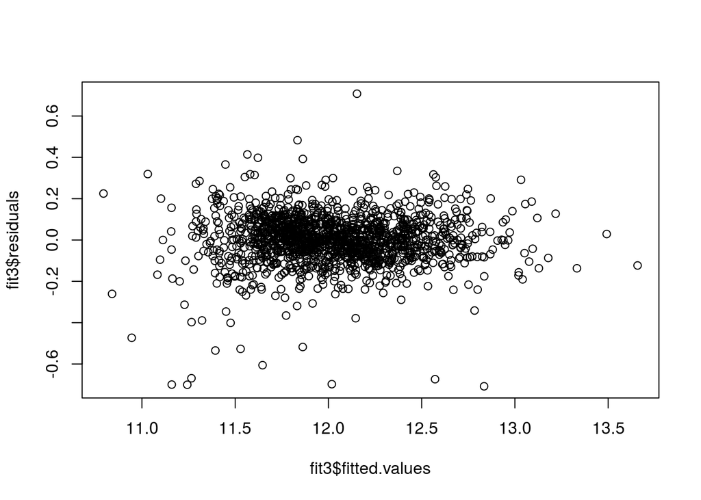

```r
plot(fit3$fitted.values,fit3$residuals)
```

분산들이 비교적 안정화되었다.

**Fit3 모델로 test 데이터 예측**

```r
exp(predict(fit3,test))
```

```
##          1          2          3          4          5          6          7
##  123861.09  160762.44  174099.46  194373.67  218677.69  176438.41  181689.91
##          8          9         10         11         12         13         14
##  166720.81  187639.26  113951.18  180953.37  100811.44   93831.50  147208.65
##         15         16         17         18         19         20         21
##  126523.13  400417.40  269570.86  308210.01  297275.99  519743.68  330775.74
##         22         23         24         25         26         27         28
##  228991.91  179099.12  161672.33  181430.49  200814.40  346126.53  254621.17
##         29         30         31         32         33         34         35
##  208738.84  226010.40  198116.34  102356.66  165210.69  280935.89  279482.69
##         36         37         38         39         40         41         42
##  209970.08  192894.30  162773.11  152825.88  144826.29  167518.37  154589.80
##         43         44         45         46         47         48         49
##  259618.27  247322.19  227544.41  183984.51  236793.89  193744.80  156243.63
##         50         51         52         53         54         55         56
##  133681.99  139278.67  168593.94  154862.41  145089.31  234288.80  150559.51
##         57         58         59         60         61         62         63
##  182826.42  134860.17  204818.73  125093.98  129501.27  178824.00  117962.03
##         64         65         66         67         68         69         70
##  134019.26  122017.67  114783.86  108314.42  144860.00  133335.44  208873.07
##         71         72         73         74         75         76         77
##  115152.73  107774.16  139478.27  135198.31  138790.59  104156.42   62656.47
##         78         79         80         81         82         83         84
##  146887.99  201666.32  103274.94  131990.94  130688.17  178141.22   93749.55
##         85         86         87         88         89         90         91
##  116761.15  133204.88  138066.97  146836.74  118115.58  120506.99  104608.90
##         92         93         94         95         96         97         98
##  120112.70  157363.23  124919.76  169514.43  100045.31  108070.71  106992.14
##         99        100        101        102        103        104        105
##   82706.39  121012.93  112186.79  126252.35  117501.62  165824.26  141905.42
##        106        107        108        109        110        111        112
##  250601.98   82277.89  220274.32  107637.71  135505.81  120290.85  132805.77
##        113        114        115        116        117        118        119
##  226505.72  114518.72  218508.70  225657.25  186576.67  144356.03  151289.97
##        120        121        122        123        124        125        126
##  198845.67  159064.52  123980.80  277873.68  233782.34  138496.18   84616.88
##        127        128        129        130        131        132        133
##  106523.41  134430.38   98232.10  139134.04  102696.13  114091.15  126616.95
##        134        135        136        137        138        139        140
##  139478.29  112086.92  219759.94  176983.29  226382.03  170083.00  169754.80
```

[output cut: 363 more lines]

```
##   86466.57  103748.59  114144.19   87773.19   57210.79  112801.79  127545.27
##       1415       1416       1417       1418       1419       1420       1421
##  115190.90  163822.35  149438.24  163807.30  127856.20  106913.58  156727.28
##       1422       1423       1424       1425       1426       1427       1428
##  185933.63  186434.99  200384.27  194654.93  248266.70   97345.88  124310.87
##       1429       1430       1431       1432       1433       1434       1435
##   72794.75   81586.16  129737.94   61600.23   98259.13   66152.21  301099.84
##       1436       1437       1438       1439       1440       1441       1442
##  265495.53  200110.16  156820.25  208458.85  149670.74  197691.45  163582.43
##       1443       1444       1445       1446       1447       1448       1449
##  311852.16  320260.57  100709.24  178084.89  116500.55  124360.38  146097.38
##       1450       1451       1452       1453       1454       1455       1456
##   81798.76   81845.33  158709.36   73412.76   80278.62   89352.85   79384.49
##       1457       1458       1459
##  143690.14  142170.16  217101.70
```

**Test 데이터에 SalePrice 만들기**

```r
test %<>% mutate(SalePrice = exp(predict(fit3,test)))
glimpse(test)
```

```
## Rows: 1,459
## Columns: 81
## $ Id            <int> 1461, 1462, 1463, 1464, 1465, 1466, 1467, 1468, 1469, 14…
## $ MSSubClass    <int> 20, 20, 60, 60, 120, 60, 20, 60, 20, 20, 120, 160, 160, …
## $ MSZoning      <chr> "RH", "RL", "RL", "RL", "RL", "RL", "RL", "RL", "RL", "R…
## $ LotFrontage   <int> 80, 81, 74, 78, 43, 75, NA, 63, 85, 70, 26, 21, 21, 24, …
## $ LotArea       <int> 11622, 14267, 13830, 9978, 5005, 10000, 7980, 8402, 1017…
## $ Street        <chr> "Pave", "Pave", "Pave", "Pave", "Pave", "Pave", "Pave", …
## $ Alley         <chr> NA, NA, NA, NA, NA, NA, NA, NA, NA, NA, NA, NA, NA, NA, …
## $ LotShape      <chr> "Reg", "IR1", "IR1", "IR1", "IR1", "IR1", "IR1", "IR1", …
## $ LandContour   <chr> "Lvl", "Lvl", "Lvl", "Lvl", "HLS", "Lvl", "Lvl", "Lvl", …
## $ Utilities     <chr> "AllPub", "AllPub", "AllPub", "AllPub", "AllPub", "AllPu…
## $ LotConfig     <chr> "Inside", "Corner", "Inside", "Inside", "Inside", "Corne…
## $ LandSlope     <chr> "Gtl", "Gtl", "Gtl", "Gtl", "Gtl", "Gtl", "Gtl", "Gtl", …
## $ Neighborhood  <chr> "NAmes", "NAmes", "Gilbert", "Gilbert", "StoneBr", "Gilb…
```

[output cut: 68 more lines]

SalePrice열 확인

**Csv 파일 생성**

```r
write.csv(test, "prediction.csv")
```

**Submission 규격에 맞게 파일 생성**

```r
ForSubmission = test %>% select(Id, SalePrice)
write.csv(ForSubmission, "ForSubmission.csv")
```